# MTH6139 Time Series

Coursework 1

Zain Chowdhury

Spring term 2025

# Introduction

Oil prices are an important indicator of global economic activity and they’re mainly influenced by geopolitical conflicts, supply disruptions and economic demand.

In this project I decided to analyse Brent crude oil prices and use Meta’s Prophet forecasting model to predict future oil prices.

# Data

```
## # A tibble: 6 × 2
##   observation_date DCOILBRENTEU
##   <date>                  <dbl>
## 1 2021-03-09               67.0
## 2 2021-03-10               67.5
## 3 2021-03-11               69.3
## 4 2021-03-12               68.9
## 5 2021-03-15               68.8
## 6 2021-03-16               68.0
```

The Brent crude oil dataset was obtained from the Federal Reserve Economic Data (FRED) database. It represents the cost of oil per barrel in USD and is a key benchmark used in global energy markets.

# Preparing the data for Prophet

```
## # A tibble: 6 × 2
##   ds             y
##   <date>     <dbl>
## 1 2021-03-09  67.0
## 2 2021-03-10  67.5
## 3 2021-03-11  69.3
## 4 2021-03-12  68.9
## 5 2021-03-15  68.8
## 6 2021-03-16  68.0
```

The dataset has been reformatted into the structure required by Prophet, where “ds” represents the date and “y” represents the oil price.

# Visualising oil prices

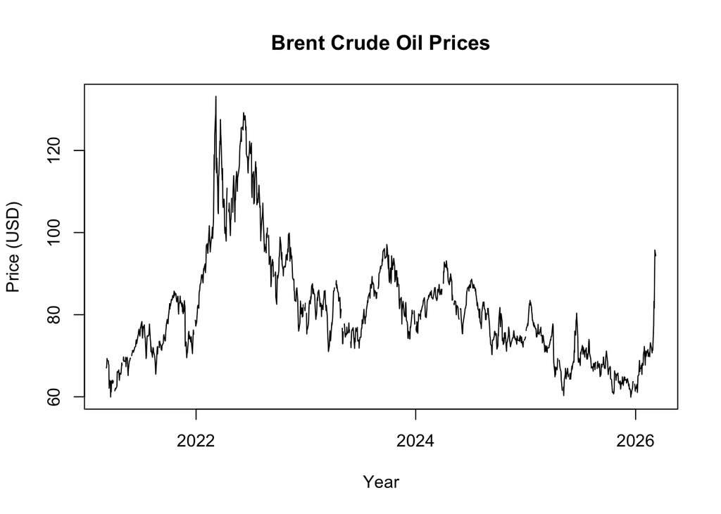

The plot shows that oil prices rise steeply between 2021 and early 2022, followed by a noticeable decline, and then continue to fluctuate in subsequent years. These movements suggest that oil prices are highly volatile and influenced by external economic and geopolitical factors rather than following a consistent long-term upward trend.

# Prophet model

```
## Disabling daily seasonality. Run prophet with daily.seasonality=TRUE to override this.
```

In this section we fit a forecasting model using Meta’s Prophet library.

# Forecasting future oil prices and components

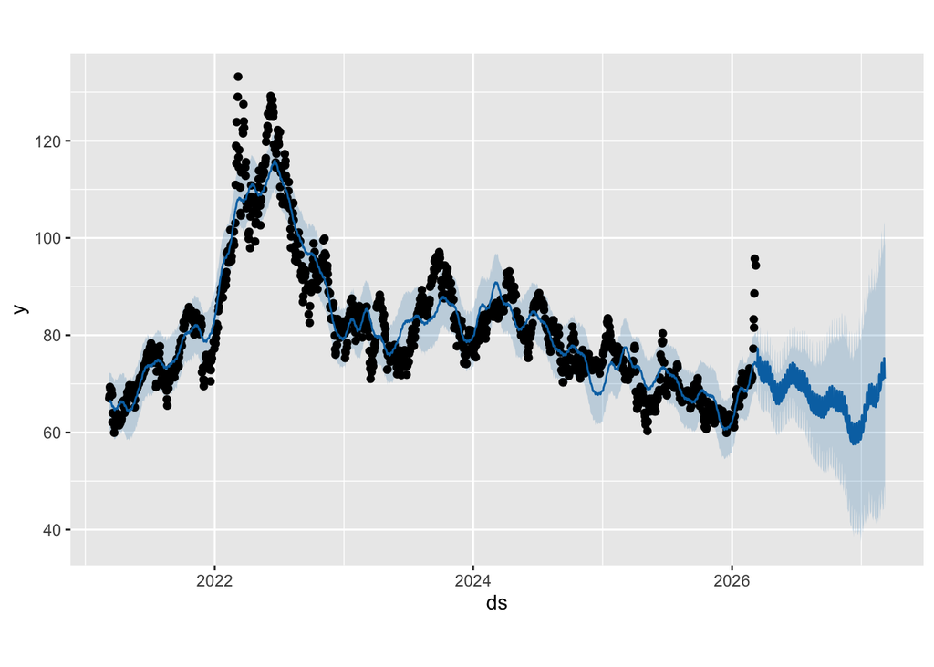

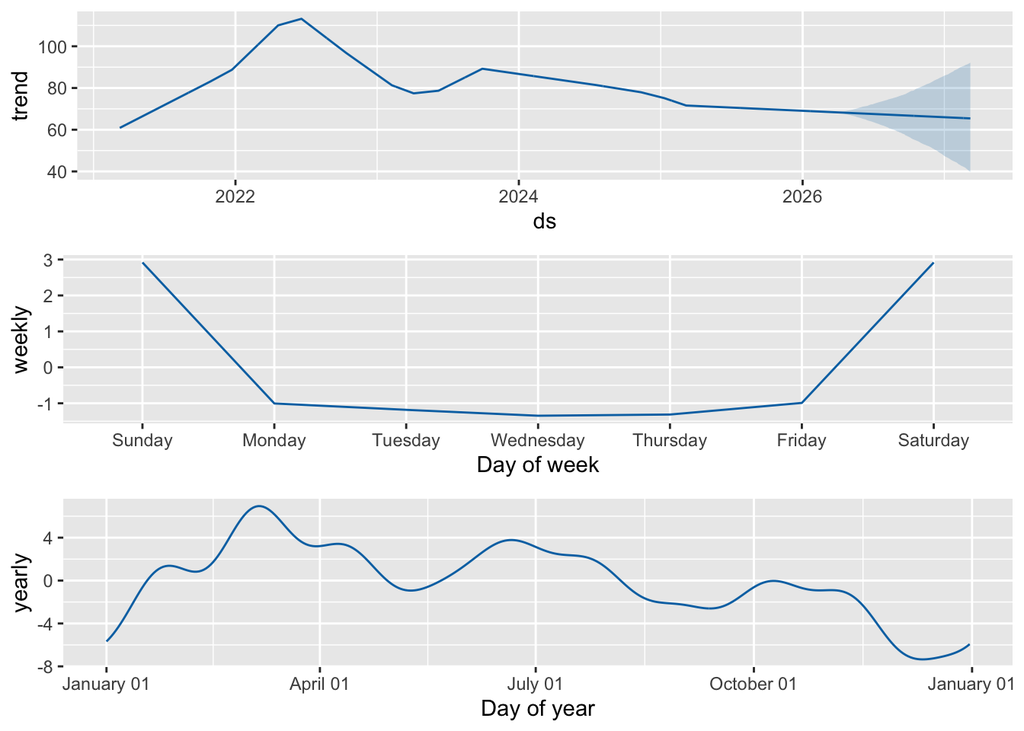

This forecast shows the predicted trajectory of oil prices based on previous trends and then decomposes this into trends and seasonal components

# Conclusion

In this project I analysed Brent crude oil prices using a time series approach and applied the Prophet model to forecast future price movements. The historical data shows that oil prices have experienced several periods of sharp increases and declines over time.

From the visualisation, oil prices tend to increase during periods of global conflict or geopolitical tension. For example, there is a significant rise in prices in early 2022, coinciding with the start of the Russia–Ukraine war. This is likely due to uncertainty in global energy markets, as Russia is a major exporter of oil and natural gas, so disruptions can create supply shortages or expectations of shortages.

The Prophet model captures the overall trend in the series and provides an estimate of how prices may evolve in the future. Although it cannot predict unexpected global events, it is useful for identifying historical patterns and generating informed forecasts based on past data.